# flight_delays_eda_binay

Binay Raut

2026-11-06

# Exploratory Data Analysis of Departure Delays

```r
library(tidyverse)
df <- readRDS("../data/ua_final.rds")

glimpse(df)
```

```
## Rows: 57,979
## Columns: 15
## $ year           <int> 2013, 2013, 2013, 2013, 2013, 2013, 2013, 2013, 2013, 2…
## $ month          <int> 1, 1, 1, 1, 1, 1, 1, 1, 1, 1, 1, 1, 1, 1, 1, 1, 1, 1, 1…
## $ day            <int> 1, 1, 1, 1, 1, 1, 1, 1, 1, 1, 1, 1, 1, 1, 1, 1, 1, 1, 1…
## $ hour           <dbl> 5, 5, 5, 6, 6, 6, 6, 6, 6, 6, 6, 6, 6, 6, 7, 7, 7, 7, 7…
## $ sched_dep_time <int> 515, 529, 558, 600, 600, 600, 607, 600, 627, 630, 646, …
## $ origin         <chr> "EWR", "LGA", "EWR", "JFK", "EWR", "EWR", "EWR", "JFK",…
## $ carrier        <chr> "UA", "UA", "UA", "UA", "UA", "UA", "UA", "UA", "UA", "…
## $ flight         <int> 1545, 1714, 1696, 194, 1124, 1187, 1077, 303, 496, 1665…
## $ dep_delay      <dbl> 2, 4, -4, -2, -2, -1, 0, 11, -4, -2, -3, 8, 1, 1, -4, -…
## $ late           <lgl> TRUE, TRUE, FALSE, FALSE, FALSE, FALSE, FALSE, TRUE, FA…
## $ very_late      <lgl> FALSE, FALSE, FALSE, FALSE, FALSE, FALSE, FALSE, FALSE,…
## $ temp           <dbl> 39.02, 39.92, 39.02, 37.94, 37.94, 37.94, 37.94, 37.94,…
## $ wind_speed     <dbl> 12.65858, 14.96014, 12.65858, 13.80936, 11.50780, 11.50…
## $ precip         <dbl> 0, 0, 0, 0, 0, 0, 0, 0, 0, 0, 0, 0, 0, 0, 0, 0, 0, 0, 0…
## $ visib          <dbl> 10, 10, 10, 10, 10, 10, 10, 10, 10, 10, 10, 10, 10, 10,…
```

## Exploratory analysis of Time of day

```r
hourly_summary <- df %>%
  group_by(hour) %>%
  summarise(
    total_flights = n(),
    mean_delay = mean(dep_delay),
    median_delay = median(dep_delay),
    sd_delay = sd(dep_delay),
    late_pct = mean(late) * 100,
    very_late_pct = mean(very_late) * 100,
    .groups = "drop"
  )

hourly_summary
```

```
## # A tibble: 19 × 7
##     hour total_flights mean_delay median_delay sd_delay late_pct very_late_pct
##    <dbl>         <int>      <dbl>        <dbl>    <dbl>    <dbl>         <dbl>
##  1     5           836       2.16           -2     16.0     33.3          3.83
##  2     6          5332       2.72           -2     20.7     30.4          4.44
##  3     7          4411       3.26           -2     22.9     30.4          4.67
##  4     8          4426       4.80           -2     25.7     32.8          6.64
##  5     9          3102       6.07           -2     28.6     36.7          7.25
##  6    10          2990       7.19           -1     30.0     37.5          8.80
##  7    11          2666       6.50           -2     29.9     36.4          7.76
##  8    12          3060       8.04           -1     33.5     36.5          9.54
##  9    13          3271      11.6             1     32.3     50.2         12.8
## 10    14          3905      12.6             1     35.4     53.6         12.3
## 11    15          4622      15.9             2     42.5     56.4         14.8
## 12    16          2720      16.5             2     41.1     55.9         16.3
## 13    17          4840      19.3             3     42.5     60.5         19.4
## 14    18          3906      22.6             5     43.2     64.1         23.9
## 15    19          2818      23.3             6     44.8     64.5         24.1
## 16    20          3873      23.1             5     43.8     61.2         25.2
## 17    21          1181      21.0             6     36.9     61.2         25.7
## 18    22            11      31.7            16     43.4     63.6         45.5
## 19    23             9      20.6            12     31.5     66.7         22.2
```

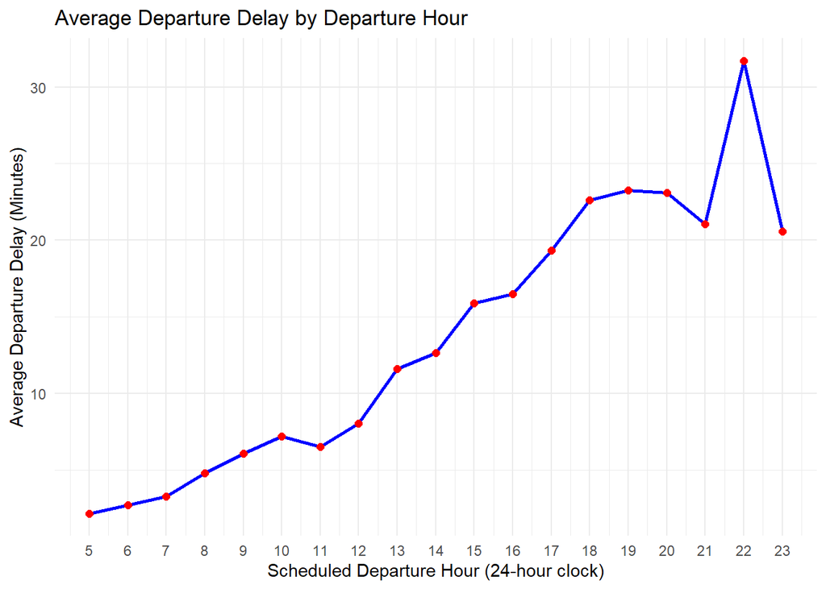

```r
hourly_summary %>%
  ggplot(aes(x = hour, y = mean_delay)) +
  geom_line(color = "blue", linewidth = 1) +
  geom_point(color = "red", size = 2) +
  scale_x_continuous(breaks = 0:23) +
  labs(
    title = "Average Departure Delay by Departure Hour",
    # subtitle = "United Airlines flights departing from NYC-area airports, 2013",
    x = "Scheduled Departure Hour (24-hour clock)",
    y = "Average Departure Delay (Minutes)"
  ) +
  theme_minimal()
```

- Early morning departures have generally lower departure delays.
- As departure time approaches afternoon and evening, the average delays rises.
- Peak delay is for departures at 10 PM.

Take a look at number of flights per hours

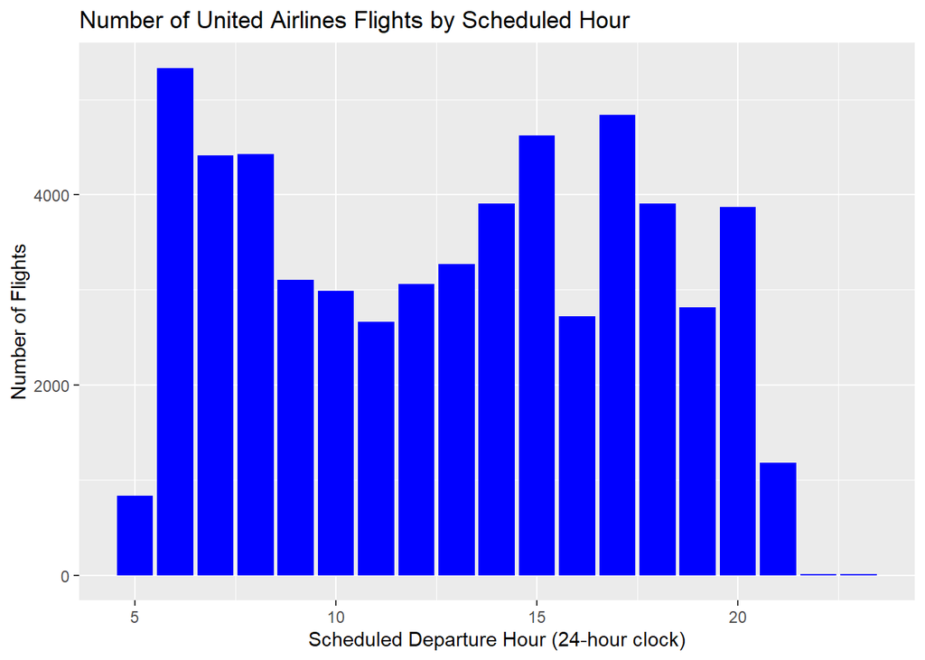

```r
hourly_summary %>%
  ggplot(aes(x = hour, y = total_flights)) +
  geom_col(fill = "blue") +
  labs(
    title = "Number of United Airlines Flights by Scheduled Hour",
    x = "Scheduled Departure Hour (24-hour clock)",
    y = "Number of Flights"
  )
```

- Although flights scheduled at 10 PM have the highest average departure delay, the number of flights scheduled during this hour is relatively small.
- Therefore, the average delay may be more sensitive to unusually long delays.
- Further examination of the median and distribution of departure delays is needed to determine whether the higher average reflects a broader pattern or the influence of extreme observations.

```r
hourly_summary %>%
  select(
    hour,
    total_flights,
    mean_delay,
    median_delay,
    sd_delay
  ) %>%
  knitr::kable(digits = 2)
```

| hour | total_flights | mean_delay | median_delay | sd_delay |
| --- | --- | --- | --- | --- |
| 5 | 836 | 2.16 | -2 | 16.03 |
| 6 | 5332 | 2.72 | -2 | 20.65 |
| 7 | 4411 | 3.26 | -2 | 22.90 |
| 8 | 4426 | 4.80 | -2 | 25.67 |
| 9 | 3102 | 6.07 | -2 | 28.64 |
| 10 | 2990 | 7.19 | -1 | 30.01 |
| 11 | 2666 | 6.50 | -2 | 29.92 |
| 12 | 3060 | 8.04 | -1 | 33.47 |
| 13 | 3271 | 11.59 | 1 | 32.30 |
| 14 | 3905 | 12.63 | 1 | 35.37 |
| 15 | 4622 | 15.90 | 2 | 42.49 |
| 16 | 2720 | 16.50 | 2 | 41.14 |
| 17 | 4840 | 19.33 | 3 | 42.55 |
| 18 | 3906 | 22.60 | 5 | 43.24 |
| 19 | 2818 | 23.26 | 6 | 44.77 |
| 20 | 3873 | 23.09 | 5 | 43.83 |
| 21 | 1181 | 21.03 | 6 | 36.90 |
| 22 | 11 | 31.73 | 16 | 43.41 |
| 23 | 9 | 20.56 | 12 | 31.46 |

Examine late vs very late flights by hour

```r
hourly_summary %>%
  select(
    hour,
    total_flights,
    late_pct,
    very_late_pct
  ) %>%
  knitr::kable(digits = 2)
```

| hour | total_flights | late_pct | very_late_pct |
| --- | --- | --- | --- |
| 5 | 836 | 33.25 | 3.83 |
| 6 | 5332 | 30.42 | 4.44 |
| 7 | 4411 | 30.42 | 4.67 |
| 8 | 4426 | 32.78 | 6.64 |
| 9 | 3102 | 36.69 | 7.25 |
| 10 | 2990 | 37.53 | 8.80 |
| 11 | 2666 | 36.38 | 7.76 |
| 12 | 3060 | 36.47 | 9.54 |
| 13 | 3271 | 50.17 | 12.78 |
| 14 | 3905 | 53.62 | 12.27 |
| 15 | 4622 | 56.45 | 14.76 |
| 16 | 2720 | 55.92 | 16.32 |
| 17 | 4840 | 60.45 | 19.38 |
| 18 | 3906 | 64.13 | 23.89 |
| 19 | 2818 | 64.55 | 24.10 |
| 20 | 3873 | 61.22 | 25.23 |
| 21 | 1181 | 61.22 | 25.74 |
| 22 | 11 | 63.64 | 45.45 |
| 23 | 9 | 66.67 | 22.22 |

The proportion of late and very late departures generally increases throughout the day. Flights scheduled at 6 AM and 7 AM have the lowest late-departure rates (30.42%), with fewer than 5% departing more than 30 minutes late. In comparison, more than 60% of flights scheduled from 5 PM onward depart late. The percentage of very late departures also increases, ranging from approximately 19% to 26% between 5 PM and 9 PM. Although the very late departure rate reaches 45.45% at 10 PM, this figure is based on only 11 flights.

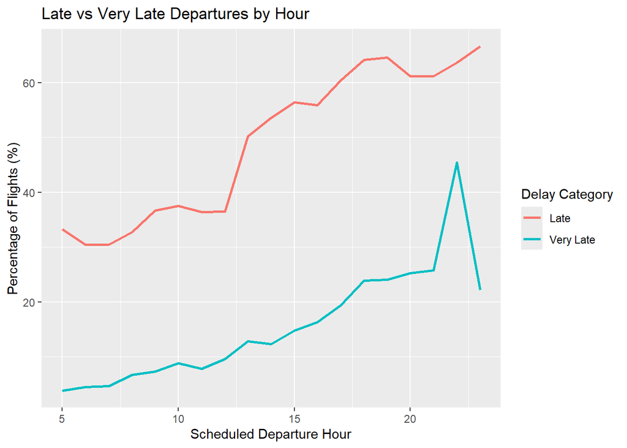

```r
hourly_summary %>%
  ggplot(aes(x = hour)) +
  geom_line(aes(y = late_pct, color = "Late"), linewidth = 1) +
  geom_line(aes(y = very_late_pct, color = "Very Late"), linewidth = 1) +
  labs(
    title = "Late vs Very Late Departures by Hour",
    x = "Scheduled Departure Hour",
    y = "Percentage of Flights (%)",
    color = "Delay Category"
  )
```

### Time of Day | Exploratory Findings

Departure delays show a noticeable relationship with scheduled departure time. Flights scheduled during the early morning generally experience shorter average delays, while flights scheduled later in the day tend to experience longer delays. For example, flights scheduled at 6 AM had an average departure delay of 2.72 minutes, compared with 22.60 minutes for flights scheduled at 6 PM. The median departure delays were considerably lower than the corresponding averages, suggesting that unusually long delays influence the mean. A similar pattern was observed when examining the proportion of late and very late flights. At 6 AM, 30.42% of flights departed late and 4.44% departed more than 30 minutes late. By 6 PM, these percentages increased to 64.13% and 23.89%, respectively. Although the highest average departure delay occurred at 10 PM, only 11 flights were scheduled during that hour. Overall, the exploratory analysis suggests that departures scheduled later in the day are associated with more frequent and longer delays. Further statistical analysis using permutation tests will help assess whether differences between broader time-of-day groups are statistically significant.

## Exploratory analysis of Wind speed

Since we know there are observations for wind speed missing in our dataset, we filter the data frame and remove observations with missing wind speed

```r
wind_speed_df <- df %>%
  drop_na(wind_speed)
```

Review summary statistics of wind speed.

```r
wind_speed_df %>%
  summarise(
    total_flights = n(),
    mean_wind = mean(wind_speed),
    median_wind = median(wind_speed),
    sd_wind = sd(wind_speed),
    min_wind = min(wind_speed),
    max_wind = max(wind_speed)
  )
```

```
## # A tibble: 1 × 6
##   total_flights mean_wind median_wind sd_wind min_wind max_wind
##           <int>     <dbl>       <dbl>   <dbl>    <dbl>    <dbl>
## 1         57669      10.3        9.21    5.41        0     42.6
```

- Mean wind speed for flights 10.3mph wht median of 9.2 mph.
- Standard deviation is 5.4.

Distribution of wind speed and number of flights

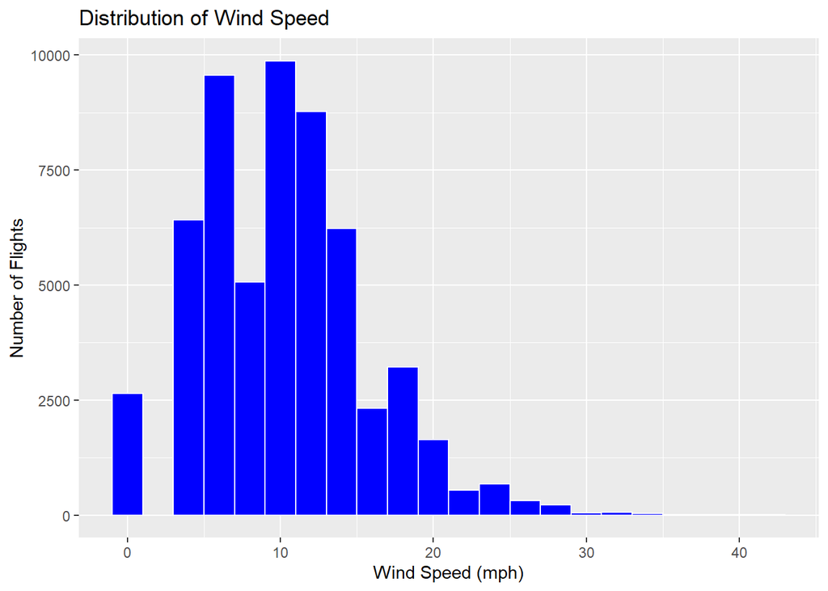

```r
wind_speed_df %>%
  ggplot(aes(x = wind_speed)) +
  geom_histogram(
    binwidth = 2,
    fill = "blue",
    color = "white"
  ) +
  labs(
    title = "Distribution of Wind Speed",
    x = "Wind Speed (mph)",
    y = "Number of Flights"
  )
```

* Most flights are between 5 to 15 miles per hour. * As wind speed approaches 20mph and more, fewer flights are happening. * Seems like a preference is low to moderate wind.

Wind Speed vs Departure Delay

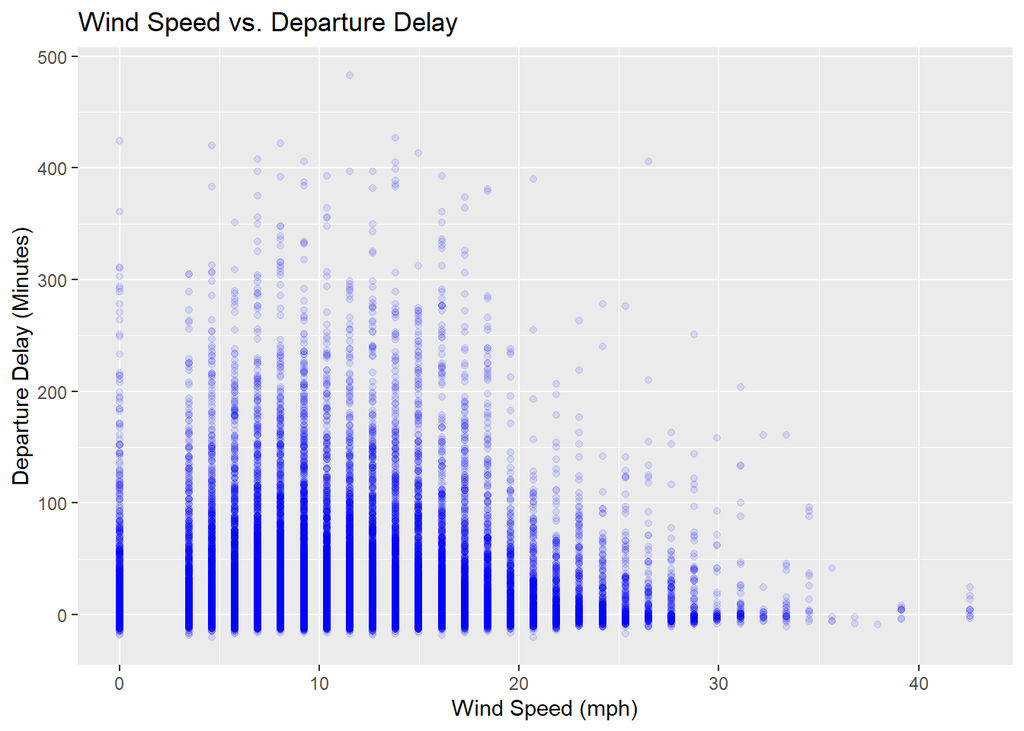

```r
wind_speed_df %>%
  ggplot(aes(x = wind_speed, y = dep_delay)) +
  geom_point(alpha = 0.1, color = "blue") +
  labs(
    title = "Wind Speed vs. Departure Delay",
    x = "Wind Speed (mph)",
    y = "Departure Delay (Minutes)"
  )
```

- Fairly consistent distribution of delays across different wind speed data.
- Does not seem to be a relationship between departure delay and wind speed.

Group wind speed by severity: low (less than 10 mph), moderate (less than 20) and rest (higher than 20) as high

```r
wind_speed_df <- wind_speed_df %>%
  mutate(
    wind_severity = case_when(
      wind_speed < 10 ~ "low",
      wind_speed < 20 ~ "moderate",
      TRUE ~ "high"
    ),
    wind_severity = factor(
      wind_severity,
      levels = c("low", "moderate", "high")
    )
  )
```

Summarize the data so we can see proportions of flights that are late and very late by wind speed category.

```r
wind_summary <- wind_speed_df %>%
  group_by(wind_severity) %>%
  summarise(
    total_flights = n(),
    mean_delay = mean(dep_delay),
    median_delay = median(dep_delay),
    late_pct = mean(late) * 100,
    very_late_pct = mean(very_late) * 100,
    .groups = "drop"
  )

wind_summary
```

```
## # A tibble: 3 × 6
##   wind_severity total_flights mean_delay median_delay late_pct very_late_pct
##   <fct>                 <int>      <dbl>        <dbl>    <dbl>         <dbl>
## 1 low                   29080       11.3            0     45.0          12.4
## 2 moderate              25961       13.0            0     48.9          13.8
## 3 high                   2628       12.3            0     48.9          14.6
```

```r
wind_summary %>%
  knitr::kable(
    digits = 2,
    col.names = c(
      "Wind Category",
      "Total Flights",
      "Mean Delay (min)",
      "Median Delay (min)",
      "Late (%)",
      "Very Late (%)"
    ),
    caption = "Departure Delays by Wind Category"
  )
```

Departure Delays by Wind Category

| Wind Category | Total Flights | Mean Delay (min) | Median Delay (min) | Late (%) | Very Late (%) |
| --- | --- | --- | --- | --- | --- |
| low | 29080 | 11.26 | 0 | 45.04 | 12.37 |
| moderate | 25961 | 13.01 | 0 | 48.93 | 13.81 |
| high | 2628 | 12.29 | 0 | 48.86 | 14.65 |

- As observed earlier, very low number of flights when the wind speed is in high category
- percentage of late and very late flights relatively similar. As the severity rises from low to moderate, the percentage of late and very late flights increases.

### Wind Speed | Exploratory Findings

The wind speed analysis showed that most United Airlines flights departed under wind conditions below 20 mph. The scatterplot did not reveal a clear linear relationship between wind speed and departure delay.

When wind speeds were grouped into severity: low , moderate, and high, the mean departure delays were 11.26, 13.01, and 12.29 minutes, respectively.

The percentage of late departures was slightly higher under moderate and high wind conditions compared with low wind conditions. Additionally, the proportion of flights departing more than 30 minutes late increased from 12.37% under low wind conditions to 14.65% under high wind conditions.

Overall, wind speed appears to have a modest association with departure delays, with slightly higher rates of substantial delays under stronger wind conditions. Further statistical analysis is needed to assess whether these observed differences are statistically significant.

## Exploratory analysis of Precipitation

Since we know there are observations for wind speed missing in our dataset, we filter the data frame and remove observations with missing Precipitation

```r
precipitation_data <- df %>%
  drop_na(precip)
```

Summary statistics

```r
precipitation_data %>%
  summarise(
    total_flights = n(),
    min_precip = min(precip),
    max_precip = max(precip),
    mean_precip = mean(precip),
    median_precip = median(precip),
    sd_precip = sd(precip),
    no_precip = sum(precip == 0),
    some_precip = sum(precip > 0)
  )
```

```
## # A tibble: 1 × 8
##   total_flights min_precip max_precip mean_precip median_precip sd_precip
##           <int>      <dbl>      <dbl>       <dbl>         <dbl>     <dbl>
## 1         57686          0       1.21     0.00509             0    0.0356
## # ℹ 2 more variables: no_precip <int>, some_precip <int>
```

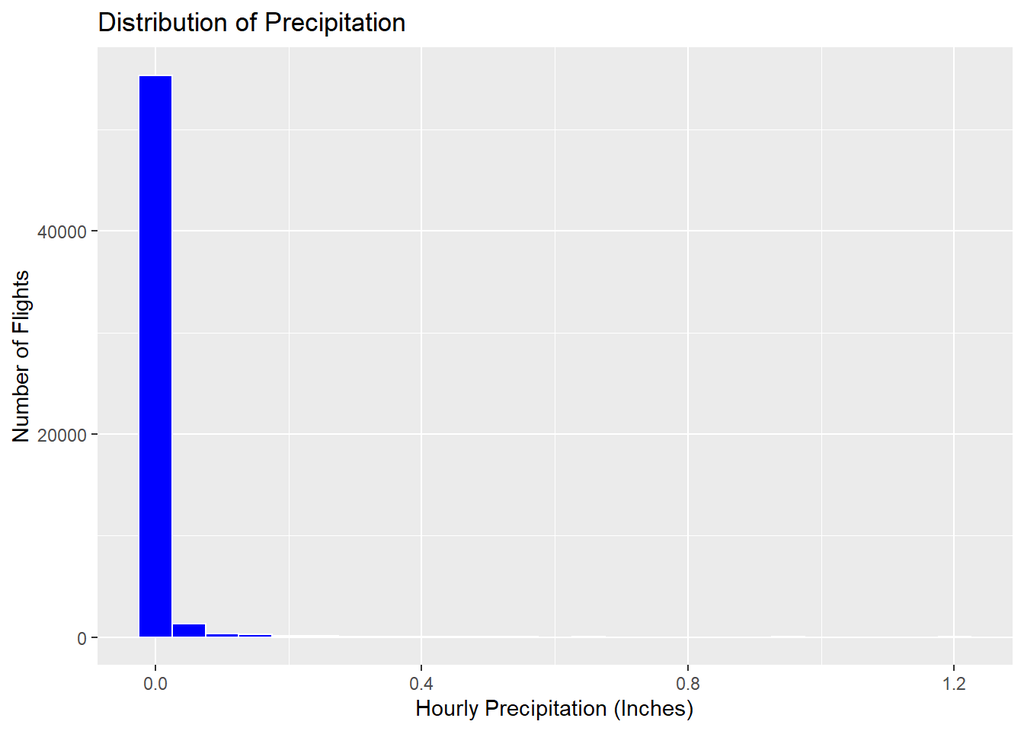

```r
precipitation_data %>%
  ggplot(aes(x = precip)) +
  geom_histogram(
    binwidth = 0.05,
    fill = "blue",
    color = "white"
  ) +
  labs(
    title = "Distribution of Precipitation",
    x = "Hourly Precipitation (Inches)",
    y = "Number of Flights"
  )
```

- Most flights occurring when there was none to minimal precipitation.

Distribution of flights by precipitation

```r
precipitation_data %>%
  summarise(
    total_flights = n(),
    dry_pct = mean(precip == 0) * 100,
    wet_pct = mean(precip > 0) * 100
  )
```

```
## # A tibble: 1 × 3
##   total_flights dry_pct wet_pct
##           <int>   <dbl>   <dbl>
## 1         57686    93.0    7.01
```

Of the 57,686 United Airlines flights with available precipitation observations, approximately 93% were scheduled during hours with no measurable precipitation, while only 7% experienced measurable precipitation.

This indicates that the precipitation distribution is heavily concentrated at zero. Because most flights occurred during dry conditions, comparing departure delays between dry and wet conditions may provide a clearer understanding of the relationship between precipitation and delays than examining the overall precipitation distribution alone.

See departure delay during wet or dry conditions.

```r
precipitation_data <- precipitation_data %>%
  mutate(wet_dry = if_else(precip == 0, "Dry", "Wet"))
```

```r
precip_summary <- precipitation_data %>%
  group_by(wet_dry) %>%
  summarise(
    total_flights = n(),
    mean_delay = mean(dep_delay),
    median_delay = median(dep_delay),
    late_pct = mean(late) * 100,
    very_late_pct = mean(very_late) * 100
  )

precip_summary
```

```
## # A tibble: 2 × 6
##   wet_dry total_flights mean_delay median_delay late_pct very_late_pct
##   <chr>           <int>      <dbl>        <dbl>    <dbl>         <dbl>
## 1 Dry             53645       11.1            0     45.7          12.2
## 2 Wet              4041       24.6            5     63.4          24.8
```

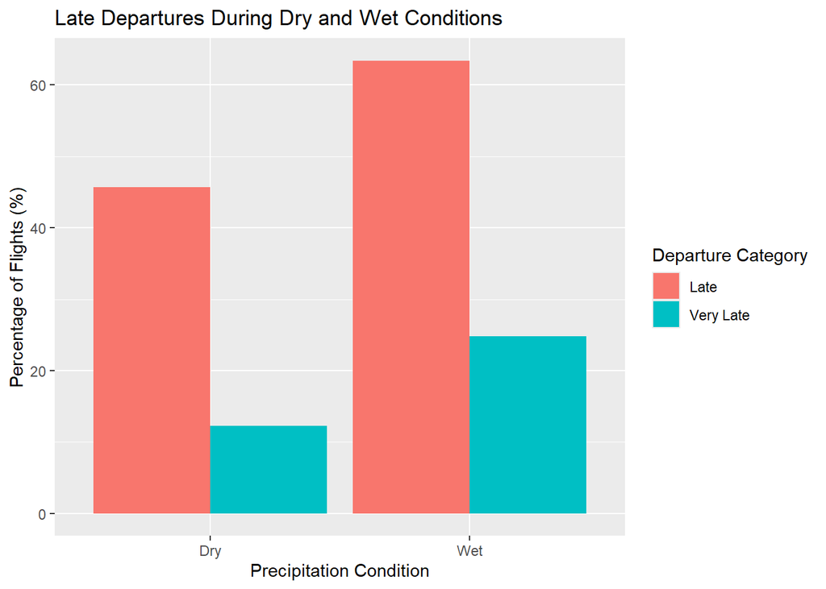

```r
precip_summary %>%
  select(wet_dry, late_pct, very_late_pct) %>%
  pivot_longer(
    cols = c(late_pct, very_late_pct),
    names_to = "delay_type",
    values_to = "percentage"
  ) %>%
  mutate(
    delay_type = recode(
      delay_type,
      late_pct = "Late",
      very_late_pct = "Very Late"
    )
  ) %>%
  ggplot(aes(
    x = wet_dry,
    y = percentage,
    fill = delay_type
  )) +
  geom_col(position = "dodge") +
  labs(
    title = "Late Departures During Dry and Wet Conditions",
    x = "Precipitation Condition",
    y = "Percentage of Flights (%)",
    fill = "Departure Category"
  )
```

The chart shows that United Airlines flights scheduled during wet conditions experienced higher rates of both late and very late departures compared with flights scheduled during dry conditions.

### Precipitation | Exploratory Findings

Departure delays were compared between dry conditions, defined as hours with no recorded precipitation, and wet conditions, defined as hours with measurable precipitation. Flights scheduled during wet conditions experienced an average departure delay of 24.63 minutes, compared with 11.15 minutes during dry conditions. The median departure delay also increased from 0 minutes under dry conditions to 5 minutes under wet conditions. The proportion of late departures increased from 45.72% under dry conditions to 63.42% under wet conditions. Similarly, the proportion of flights departing more than 30 minutes late increased from 12.24% to 24.80%. Overall, the exploratory analysis indicates that precipitation is associated with longer and more frequent departure delays.

## Exploratory analysis of Time of year

```r
glimpse(df)
```

```
## Rows: 57,979
## Columns: 15
## $ year           <int> 2013, 2013, 2013, 2013, 2013, 2013, 2013, 2013, 2013, 2…
## $ month          <int> 1, 1, 1, 1, 1, 1, 1, 1, 1, 1, 1, 1, 1, 1, 1, 1, 1, 1, 1…
## $ day            <int> 1, 1, 1, 1, 1, 1, 1, 1, 1, 1, 1, 1, 1, 1, 1, 1, 1, 1, 1…
## $ hour           <dbl> 5, 5, 5, 6, 6, 6, 6, 6, 6, 6, 6, 6, 6, 6, 7, 7, 7, 7, 7…
## $ sched_dep_time <int> 515, 529, 558, 600, 600, 600, 607, 600, 627, 630, 646, …
## $ origin         <chr> "EWR", "LGA", "EWR", "JFK", "EWR", "EWR", "EWR", "JFK",…
## $ carrier        <chr> "UA", "UA", "UA", "UA", "UA", "UA", "UA", "UA", "UA", "…
## $ flight         <int> 1545, 1714, 1696, 194, 1124, 1187, 1077, 303, 496, 1665…
## $ dep_delay      <dbl> 2, 4, -4, -2, -2, -1, 0, 11, -4, -2, -3, 8, 1, 1, -4, -…
## $ late           <lgl> TRUE, TRUE, FALSE, FALSE, FALSE, FALSE, FALSE, TRUE, FA…
## $ very_late      <lgl> FALSE, FALSE, FALSE, FALSE, FALSE, FALSE, FALSE, FALSE,…
## $ temp           <dbl> 39.02, 39.92, 39.02, 37.94, 37.94, 37.94, 37.94, 37.94,…
## $ wind_speed     <dbl> 12.65858, 14.96014, 12.65858, 13.80936, 11.50780, 11.50…
## $ precip         <dbl> 0, 0, 0, 0, 0, 0, 0, 0, 0, 0, 0, 0, 0, 0, 0, 0, 0, 0, 0…
## $ visib          <dbl> 10, 10, 10, 10, 10, 10, 10, 10, 10, 10, 10, 10, 10, 10,…
```

```r
monthly_summary <- df %>%
  group_by(month) %>%
  summarise(
    total_flights = n(),
    mean_delay = mean(dep_delay),
    median_delay = median(dep_delay),
    sd_delay = sd(dep_delay),
    late_pct = mean(late) * 100,
    very_late_pct = mean(very_late) * 100,
    .groups = "drop"
  )


monthly_summary %>%
  mutate(month = month.name[month]) %>%
  knitr::kable(
    digits = 2,
    col.names = c(
      "Month",
      "Total Flights (count)",
      "Mean Delay (minutes)",
      "Median Delay (minutes)",
      "SD Delay (minutes)",
      "Late (%)",
      "Very Late (%)"
    ),
    caption = "Departure Delays by Month"
  )
```

Departure Delays by Month

| Month | Total Flights (count) | Mean Delay (minutes) | Median Delay (minutes) | SD Delay (minutes) | Late (%) | Very Late (%) |
| --- | --- | --- | --- | --- | --- | --- |
| January | 4605 | 8.33 | 0 | 28.96 | 44.95 | 9.32 |
| February | 4166 | 7.71 | -1 | 26.37 | 42.75 | 9.24 |
| March | 4926 | 11.69 | 0 | 35.73 | 46.04 | 13.01 |
| April | 4992 | 13.65 | -1 | 39.10 | 44.79 | 15.02 |
| May | 4910 | 12.26 | 0 | 34.22 | 49.04 | 13.50 |
| June | 4910 | 20.27 | 2 | 45.82 | 56.07 | 20.18 |
| July | 5000 | 20.11 | 2 | 47.04 | 56.04 | 19.66 |
| August | 5106 | 12.42 | 0 | 33.92 | 49.31 | 13.57 |
| September | 4653 | 6.89 | -2 | 34.79 | 33.51 | 7.61 |
| October | 5040 | 6.65 | -1 | 27.18 | 37.60 | 8.41 |
| November | 4838 | 6.37 | -1 | 26.92 | 38.14 | 8.00 |
| December | 4833 | 17.72 | 5 | 35.36 | 64.68 | 18.97 |

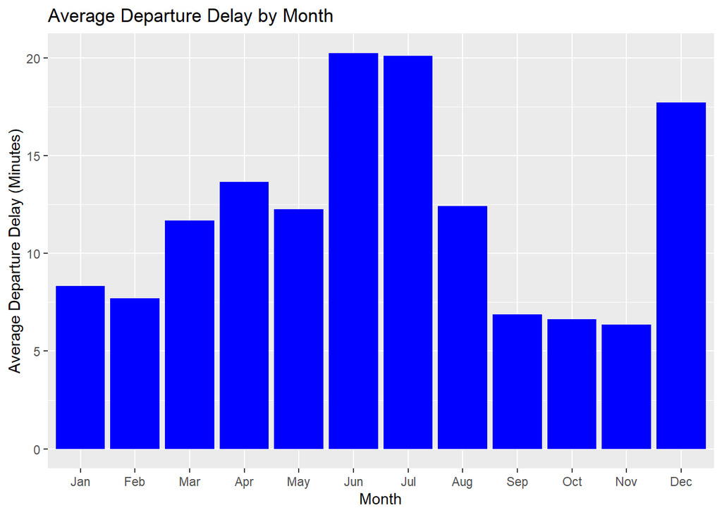

```r
monthly_summary %>%
  ggplot(aes(x = factor(month), y = mean_delay)) +
  geom_col(fill = "blue") +
  labs(
    title = "Average Departure Delay by Month",
    x = "Month",
    y = "Average Departure Delay (Minutes)"
  ) +
  scale_x_discrete(labels = month.abb)
```

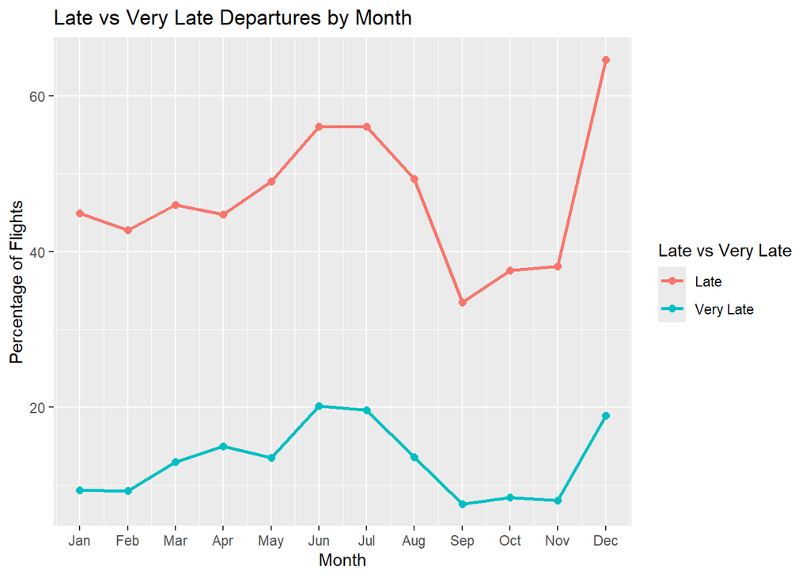

```r
monthly_summary %>%
  ggplot(aes(x = month)) +
  geom_line(
    aes(y = late_pct, color = "Late"),
    linewidth = 1
  ) +
  geom_line(
    aes(y = very_late_pct, color = "Very Late"),
    linewidth = 1
  ) +
  geom_point(
    aes(y = late_pct, color = "Late"),
    size = 2
  ) +
  geom_point(
    aes(y = very_late_pct, color = "Very Late"),
    size = 2
  ) +
  scale_x_continuous(
    breaks = 1:12,
    labels = month.abb
  ) +
  labs(
    title = "Late vs Very Late Departures by Month",
    x = "Month",
    y = "Percentage of Flights",
    color = "Late vs Very Late"
  )
```

### Time of Year | Exploratory Findings

Number of flights are approximately evenly distributed between all 12 months. Departure delays varied throughout the year. June and July experienced the longest average departure delays, at approximately 20 minutes. Additionally, June and July also had the one of the highest percentages of late and very late departures, with over 56% of flights departing late and approximately 20% of flights departing more than 30 minutes late. The month of December also had a high percentage of delays with an average delay of 17.72 minutes. December had the highest percentage of flights late with 64.68% of flights late.  
September, October, and November experienced shorter average delays of around 6 to 7 minutes and lower rates of late and very late delays. This shows that departure delays and proportion of late and very late delays are higher during early summer months and December.

## Exploratory analysis of Temperature

Prepare dataset for analysis of temperature as it relates to departure delay

```r
temperature_data <- df %>%
  drop_na(temp)
```

Review summary statistics.

```r
temperature_data %>%
  summarise(
    total_flights = n(),
    min_temp = min(temp),
    max_temp = max(temp),
    mean_temp = mean(temp),
    median_temp = median(temp),
    sd_temp = sd(temp)
  )
```

```
## # A tibble: 1 × 6
##   total_flights min_temp max_temp mean_temp median_temp sd_temp
##           <int>    <dbl>    <dbl>     <dbl>       <dbl>   <dbl>
## 1         57679     10.9     100.      57.4        57.9    18.4
```

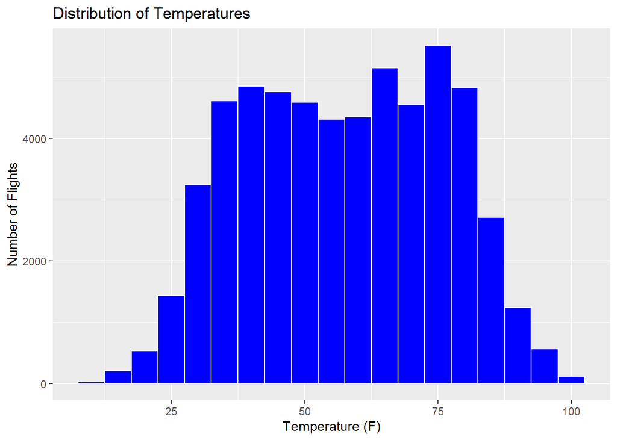

```r
temperature_data %>%
  ggplot(aes(x = temp)) +
  geom_histogram(
    binwidth = 5,
    fill = "blue",
    color = "white"
  ) +
  labs(
    title = "Distribution of Temperatures",
    x = "Temperature (F)",
    y = "Number of Flights"
  )
```

Most United Airlines flights occurred at temperatures between approximately 30°F and 85°F, with relatively few flights experiencing extremely cold or hot conditions. The mean and median temperatures were approximately 57°F and 58°F, respectively. The distribution of flights across temperature was generally uniform.

Temperature and Departure delaty

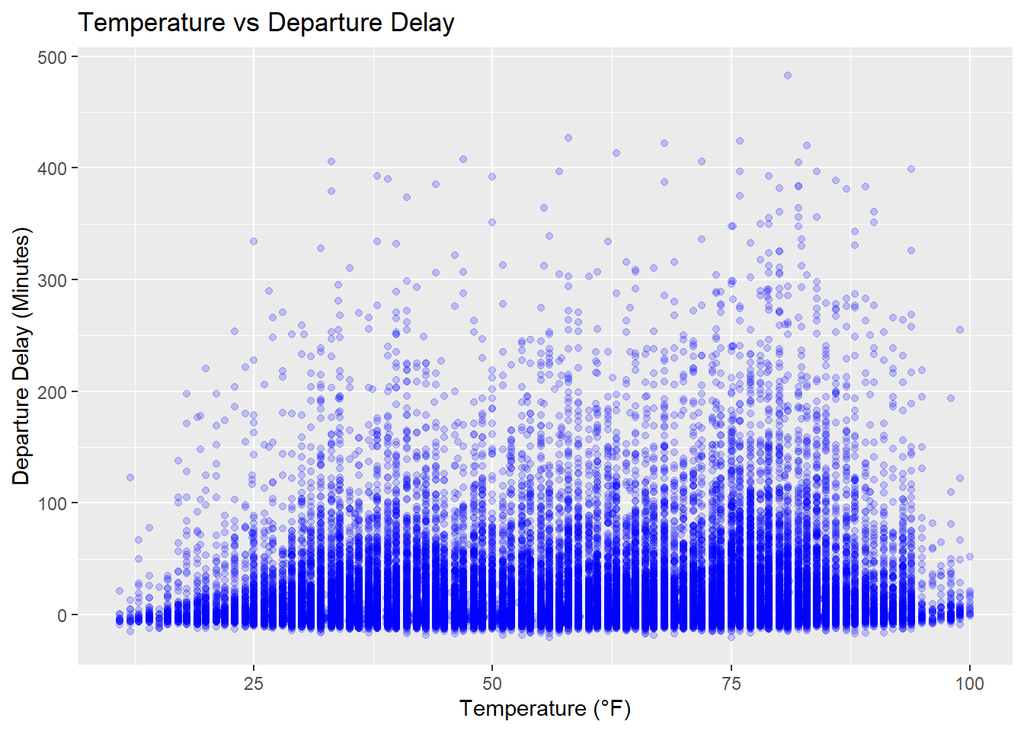

```r
temperature_data %>%
  ggplot(aes(x = temp, y = dep_delay)) +
  geom_point(alpha = 0.2, color = "blue") +
  labs(
    title = "Temperature vs Departure Delay",
    x = "Temperature (°F)",
    y = "Departure Delay (Minutes)"
  )
```

No strong linear relationship between temperature and departure delay.

Group temperature into categories

```r
temperature_data <- temperature_data %>%
  mutate(
    temp_category = case_when(
      temp < 40 ~ "Cold",
      temp < 80 ~ "Moderate",
      TRUE ~ "Hot"
    )
  )
```

View summary by temperature category

```r
temp_summary <- temperature_data %>%
  group_by(temp_category) %>%
  summarise(
    total_flights = n(),
    mean_delay = mean(dep_delay),
    median_delay = median(dep_delay),
    late_pct = mean(late) * 100,
    very_late_pct = mean(very_late) * 100,
    .groups = "drop"
  )

temp_summary
```

```
## # A tibble: 3 × 6
##   temp_category total_flights mean_delay median_delay late_pct very_late_pct
##   <chr>                 <int>      <dbl>        <dbl>    <dbl>         <dbl>
## 1 Cold                  13033       9.94            0     47.4          11.1
## 2 Hot                    7371      20.3             3     57.6          19.3
## 3 Moderate              37275      11.2             0     44.7          12.6
```

```r
temp_summary %>%
  knitr::kable(
    digits = 2,
    col.names = c(
      "Temperature Category",
      "Total Flights",
      "Mean Delay (min)",
      "Median Delay (min)",
      "Late (%)",
      "Very Late (%)"
    ),
    caption = "Departure Delays by Temperature Category"
  )
```

Departure Delays by Temperature Category

| Temperature Category | Total Flights | Mean Delay (min) | Median Delay (min) | Late (%) | Very Late (%) |
| --- | --- | --- | --- | --- | --- |
| Cold | 13033 | 9.94 | 0 | 47.43 | 11.09 |
| Hot | 7371 | 20.27 | 3 | 57.62 | 19.25 |
| Moderate | 37275 | 11.23 | 0 | 44.69 | 12.61 |

### Temperature | Exploratory Findings

Departure delays varied across temperature categories. Flights departing under hot conditions (80°F or higher) experienced the longest average delays, approximately 20.27 minutes, compared with 11.23 minutes under moderate conditions and 9.94 minutes under cold conditions. Hot conditions also had the highest proportions of late and very late departures, at 57.62% and 19.25%, respectively. In contrast, moderate temperatures had the lowest proportion of late departures, at approximately 44.69%. These findings suggest an association between higher temperatures and increased departure delays.

## Exploratory analysis of Visibility

Prepare dataset for analysis of visibility as it relates to departure delay

```r
visibility_data <- df %>%
  drop_na(visib)
```

Calculate summary statistics for visibility

```r
visibility_data %>%
  summarise(
    total_flights = n(),
    min_visib = min(visib),
    max_visib = max(visib),
    mean_visib = mean(visib),
    median_visib = median(visib),
    sd_visib = sd(visib)
  )
```

```
## # A tibble: 1 × 6
##   total_flights min_visib max_visib mean_visib median_visib sd_visib
##           <int>     <dbl>     <dbl>      <dbl>        <dbl>    <dbl>
## 1         57686         0        10       9.27           10     1.99
```

- Observations ranged from 0 to 10 miles, with a mean of approximately 9.27 miles and a median of 10 miles.

Analyze distribution of flights by visibility conditions. Normal visibility being 10 miles and higher. Reduced visibility being less than 10 mph.

```r
visibility_data %>%
  summarise(
    total_flights = n(),
    normal_visibility = sum(visib == 10),
    reduced_visibility = sum(visib < 10),
    pct_normal = mean(visib == 10) * 100,
    pct_reduced = mean(visib < 10) * 100
  )
```

```
## # A tibble: 1 × 5
##   total_flights normal_visibility reduced_visibility pct_normal pct_reduced
##           <int>             <int>              <int>      <dbl>       <dbl>
## 1         57686             47888               9798       83.0        17.0
```

Of the 57,686 United Airlines flights with available visibility observations, approximately 83% occurred when visibility was recorded at 10 miles, while 17% occurred under reduced visibility conditions (below 10 miles).

Departure delay vs Visibility

```r
visibility_data <- visibility_data %>%
  mutate(
    visibility_group = if_else(
      visib < 10,
      "Reduced",
      "Normal"
    )
  )

visibility_summary <- visibility_data %>%
  group_by(visibility_group) %>%
  summarise(
    total_flights = n(),
    mean_delay = mean(dep_delay),
    median_delay = median(dep_delay),
    late_pct = mean(late) * 100,
    very_late_pct = mean(very_late) * 100,
    .groups = "drop"
  )

visibility_summary
```

```
## # A tibble: 2 × 6
##   visibility_group total_flights mean_delay median_delay late_pct very_late_pct
##   <chr>                    <int>      <dbl>        <dbl>    <dbl>         <dbl>
## 1 Normal                   47888       11.1            0     46.1          12.2
## 2 Reduced                   9798       17.0            1     51.3          17.5
```

```r
visibility_summary %>%
  knitr::kable(
    digits = 2,
    col.names = c(
      "Visibility Condition",
      "Total Flights",
      "Mean Delay (min)",
      "Median Delay (min)",
      "Late (%)",
      "Very Late (%)"
    ),
    caption = "Departure Delays by Visibility Condition"
  )
```

Departure Delays by Visibility Condition

| Visibility Condition | Total Flights | Mean Delay (min) | Median Delay (min) | Late (%) | Very Late (%) |
| --- | --- | --- | --- | --- | --- |
| Normal | 47888 | 11.08 | 0 | 46.08 | 12.23 |
| Reduced | 9798 | 17.03 | 1 | 51.31 | 17.47 |

### Visibility | Exploratory Findings

Flights operating under reduced visibility experienced longer average departure delays of approximately 17.03 minutes, compared with 11.08 minutes under normal recorded visibility. Additionally, the proportion of late departures was also higher under reduced visibility, at 51.31%, compared with 46.08% under normal visibility. Similarly, very late departures occurred in 17.47% of flights under reduced visibility, compared with 12.23% under normal visibility. Overall, the results suggest that reduced visibility is associated with longer and more frequent departure delays.